# Red Wine Analysis by Jonas Machado Brunetto

# Seção de Gráficos Univariados

Primeiro iremos conhecer nosso dataset, ver quais são suas colunas, variaveis e dimensões

#### Variaveis

```
##  [1] "X"                    "fixed.acidity"        "volatile.acidity"
##  [4] "citric.acid"          "residual.sugar"       "chlorides"
##  [7] "free.sulfur.dioxide"  "total.sulfur.dioxide" "density"
## [10] "pH"                   "sulphates"            "alcohol"
## [13] "quality"
```

#### Dimensão

```r
str(wine)
```

```
## 'data.frame':    1599 obs. of  13 variables:
##  $ X                   : int  1 2 3 4 5 6 7 8 9 10 ...
##  $ fixed.acidity       : num  7.4 7.8 7.8 11.2 7.4 7.4 7.9 7.3 7.8 7.5 ...
##  $ volatile.acidity    : num  0.7 0.88 0.76 0.28 0.7 0.66 0.6 0.65 0.58 0.5 ...
##  $ citric.acid         : num  0 0 0.04 0.56 0 0 0.06 0 0.02 0.36 ...
##  $ residual.sugar      : num  1.9 2.6 2.3 1.9 1.9 1.8 1.6 1.2 2 6.1 ...
##  $ chlorides           : num  0.076 0.098 0.092 0.075 0.076 0.075 0.069 0.065 0.073 0.071 ...
##  $ free.sulfur.dioxide : num  11 25 15 17 11 13 15 15 9 17 ...
##  $ total.sulfur.dioxide: num  34 67 54 60 34 40 59 21 18 102 ...
##  $ density             : num  0.998 0.997 0.997 0.998 0.998 ...
##  $ pH                  : num  3.51 3.2 3.26 3.16 3.51 3.51 3.3 3.39 3.36 3.35 ...
##  $ sulphates           : num  0.56 0.68 0.65 0.58 0.56 0.56 0.46 0.47 0.57 0.8 ...
##  $ alcohol             : num  9.4 9.8 9.8 9.8 9.4 9.4 9.4 10 9.5 10.5 ...
##  $ quality             : int  5 5 5 6 5 5 5 7 7 5 ...
```

```r
dim(wine)
```

```
## [1] 1599   13
```

#### Estatísticas

```r
summary(wine)
```

```
##        X          fixed.acidity   volatile.acidity  citric.acid
##  Min.   :   1.0   Min.   : 4.60   Min.   :0.1200   Min.   :0.000
##  1st Qu.: 400.5   1st Qu.: 7.10   1st Qu.:0.3900   1st Qu.:0.090
##  Median : 800.0   Median : 7.90   Median :0.5200   Median :0.260
##  Mean   : 800.0   Mean   : 8.32   Mean   :0.5278   Mean   :0.271
##  3rd Qu.:1199.5   3rd Qu.: 9.20   3rd Qu.:0.6400   3rd Qu.:0.420
##  Max.   :1599.0   Max.   :15.90   Max.   :1.5800   Max.   :1.000
##  residual.sugar     chlorides       free.sulfur.dioxide
##  Min.   : 0.900   Min.   :0.01200   Min.   : 1.00
##  1st Qu.: 1.900   1st Qu.:0.07000   1st Qu.: 7.00
##  Median : 2.200   Median :0.07900   Median :14.00
##  Mean   : 2.539   Mean   :0.08747   Mean   :15.87
##  3rd Qu.: 2.600   3rd Qu.:0.09000   3rd Qu.:21.00
##  Max.   :15.500   Max.   :0.61100   Max.   :72.00
##  total.sulfur.dioxide    density             pH          sulphates
##  Min.   :  6.00       Min.   :0.9901   Min.   :2.740   Min.   :0.3300
##  1st Qu.: 22.00       1st Qu.:0.9956   1st Qu.:3.210   1st Qu.:0.5500
##  Median : 38.00       Median :0.9968   Median :3.310   Median :0.6200
##  Mean   : 46.47       Mean   :0.9967   Mean   :3.311   Mean   :0.6581
##  3rd Qu.: 62.00       3rd Qu.:0.9978   3rd Qu.:3.400   3rd Qu.:0.7300
##  Max.   :289.00       Max.   :1.0037   Max.   :4.010   Max.   :2.0000
##     alcohol         quality
##  Min.   : 8.40   Min.   :3.000
##  1st Qu.: 9.50   1st Qu.:5.000
##  Median :10.20   Median :6.000
##  Mean   :10.42   Mean   :5.636
##  3rd Qu.:11.10   3rd Qu.:6.000
##  Max.   :14.90   Max.   :8.000
```

# Análise Univariada

Primeiro, quero analizar o principal atributo do dataset em minha opinião, a variavel **qualidade**. E antes de começar a realizar correlações entre váriaveis, tambem vou analisar a distribuição de cada atributo individualmente.

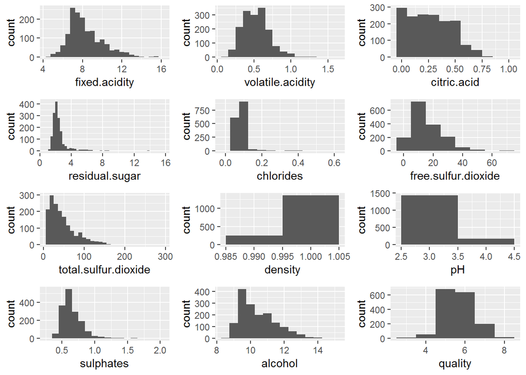

```r
gg_list1 = list(ggplot(data=wine, aes(x=fixed.acidity)) +
                  geom_histogram(binwidth = .5),
                ggplot(data=wine, aes(x=volatile.acidity)) +
                  geom_histogram(binwidth = 0.1),
                ggplot(data=wine, aes(x=citric.acid)) +
                  geom_histogram(binwidth = 0.1))
gg_list2 = list(ggplot(data=wine, aes(x=residual.sugar)) +
                  geom_histogram(binwidth = 0.3),
                ggplot(data=wine, aes(x=chlorides)) +
                  geom_histogram(binwidth = 0.05),
                ggplot(data=wine, aes(x=free.sulfur.dioxide)) +
                  geom_histogram(binwidth = 10))
gg_list3 = list(ggplot(data=wine, aes(x=total.sulfur.dioxide)) +
                  geom_histogram(binwidth = 10),
                ggplot(data=wine, aes(x=density)) +
                  geom_histogram(binwidth = 0.01),
                ggplot(data=wine, aes(x=pH)) +
                  geom_histogram(binwidth = 1))
gg_list4 = list(ggplot(data=wine, aes(x=sulphates)) +
                  geom_histogram(binwidth = 0.1),
                ggplot(data=wine, aes(x=alcohol)) +
                  geom_histogram(binwidth = 0.5),
                ggplot(data=wine, aes(x=quality)) +
                  geom_histogram(binwidth = 1))
do.call(grid.arrange,c(gg_list1,gg_list2 ,gg_list3, gg_list4 , ncol = 3, nrow  =4))
```

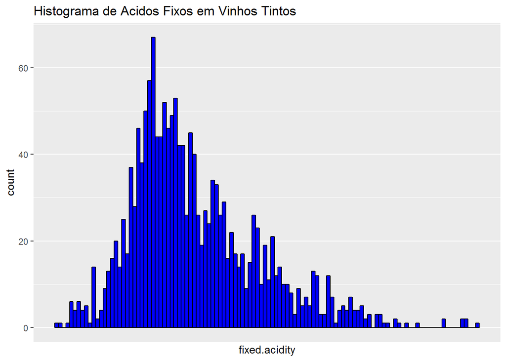

```r
ggplot(data = wine, aes(x=fixed.acidity))+
  geom_histogram(binwidth = 0.1, color = 'black', fill = 'blue')+
  xlim(4.5, 16)+
  scale_x_continuous(breaks = seq(0,1,0.1))+
  labs(title = 'Histograma de Acidos Fixos em Vinhos Tintos')
```

```r
#ggplot(data = wine, aes(x=fixed.acidity))+
#  geom_histogram(binwidth = 0.05, color = 'black', fill = 'blue')+
#  xlim(0, quantile(wine$fixed.acidity, 0.98))+
#  scale_x_continuous(breaks = seq(0,1,0.1))+
#  labs(title = 'Histograma de Acidos Fixos em Vinhos Tintos')
```

A distribuição acima mostra uma concentração após o inicio da serie, e termina com alguns outliers e uma cauda relativamente curta.

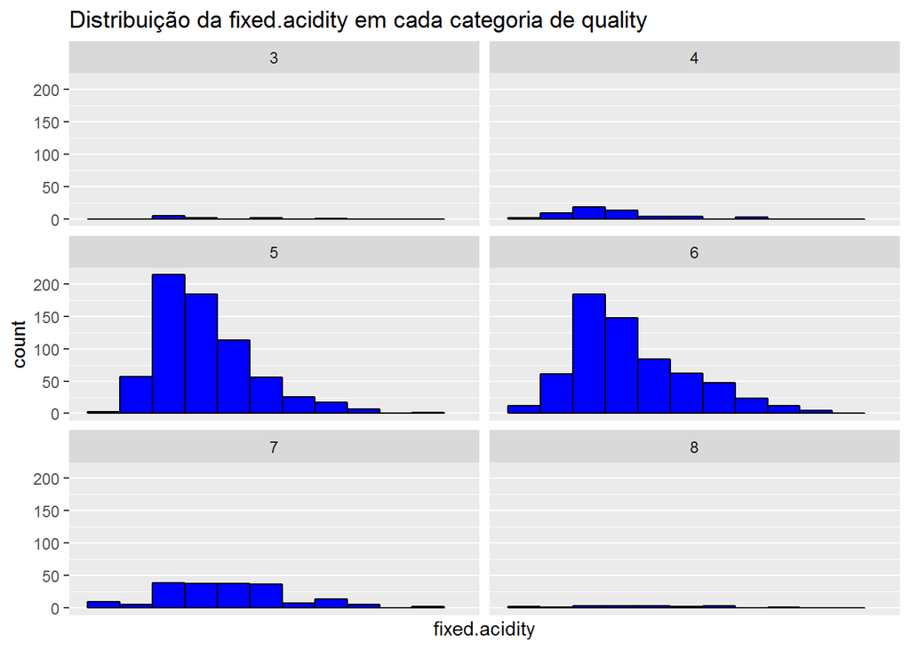

```r
ggplot(data = wine, aes(x=fixed.acidity))+
  geom_histogram(binwidth = 1, color = 'black', fill = 'blue')+
  scale_x_continuous(limits = c(4.5, 16), breaks = seq(0,1,0.1))+
  facet_wrap(  ~ quality, ncol=2)+
  labs(title = 'Distribuição da fixed.acidity em cada categoria de quality')
```

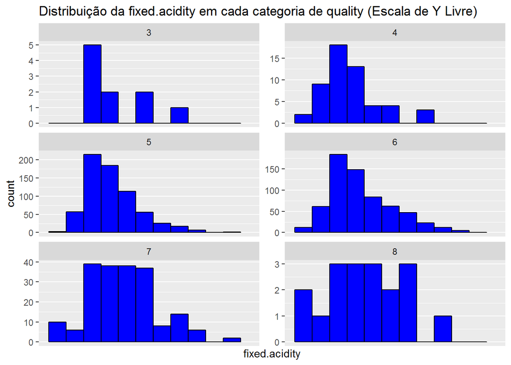

```r
ggplot(data = wine, aes(x=fixed.acidity))+
  geom_histogram(binwidth = 1, color = 'black', fill = 'blue')+
  scale_x_continuous(limits = c(4.5, 16), breaks = seq(0,1,0.1))+
  facet_wrap(  ~ quality, ncol=2, scales = 'free_y')+
  labs(title = 'Distribuição da fixed.acidity em cada categoria de quality (Escala de Y Livre)')
```

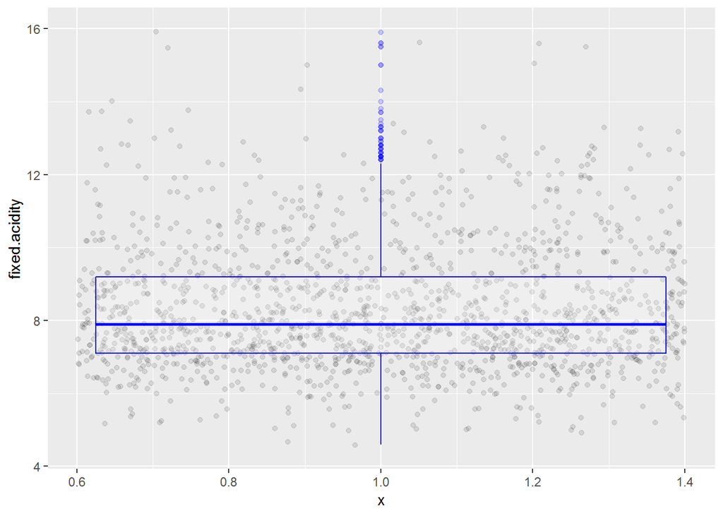

```r
ggplot(wine, aes( x = 1, y = fixed.acidity ), xlab('Count of wines') ) +
               geom_jitter(alpha = 0.1 ) + # Alpha = 10% (10 pontos para virar um ponto completo)
               geom_boxplot(alpha = 0.2, color = 'blue' ) +
               scale_y_continuous(lim = c(4.5, 16))
```

```r
by(wine$fixed.acidity, wine$quality, sum)
```

```
## wine$quality: 3
## [1] 83.6
## --------------------------------------------------------
## wine$quality: 4
## [1] 412.3
## --------------------------------------------------------
## wine$quality: 5
## [1] 5561.9
## --------------------------------------------------------
## wine$quality: 6
## [1] 5325.5
## --------------------------------------------------------
## wine$quality: 7
## [1] 1765.6
## --------------------------------------------------------
## wine$quality: 8
## [1] 154.2
```

```r
by(wine$fixed.acidity, wine$quality, summary)
```

```
## wine$quality: 3
##    Min. 1st Qu.  Median    Mean 3rd Qu.    Max.
##   6.700   7.150   7.500   8.360   9.875  11.600
## --------------------------------------------------------
## wine$quality: 4
##    Min. 1st Qu.  Median    Mean 3rd Qu.    Max.
##   4.600   6.800   7.500   7.779   8.400  12.500
## --------------------------------------------------------
## wine$quality: 5
##    Min. 1st Qu.  Median    Mean 3rd Qu.    Max.
##   5.000   7.100   7.800   8.167   8.900  15.900
## --------------------------------------------------------
## wine$quality: 6
##    Min. 1st Qu.  Median    Mean 3rd Qu.    Max.
##   4.700   7.000   7.900   8.347   9.400  14.300
## --------------------------------------------------------
## wine$quality: 7
##    Min. 1st Qu.  Median    Mean 3rd Qu.    Max.
##   4.900   7.400   8.800   8.872  10.100  15.600
## --------------------------------------------------------
## wine$quality: 8
##    Min. 1st Qu.  Median    Mean 3rd Qu.    Max.
##   5.000   7.250   8.250   8.567  10.225  12.600
```

Como fica evidente no primeiro grafico, temos uma quantidade de amostras muito superior nas categorias de qualidade 5 e qualidade 6, seguido pela Qualidade 7. Para melhor visualização das outras categorias criei o gráfico **Distribuição da fixed.acidity em cada categoria de quality (Escala de Y Livre)** onde percebemos que a qualidade 3 e 8 tem poucas amostras para cada fixed.acidity.

#### “volatile.acidity”

Def: The amount of acetic acid in wine, which at too high of levels can lead to an unpleasant, vinegar taste

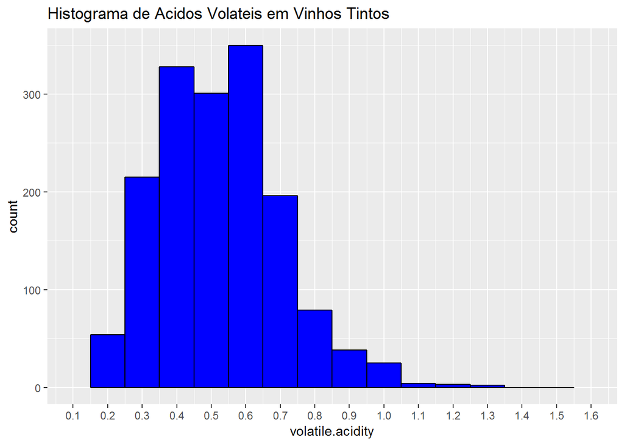

```r
ggplot(data = wine, aes(x=volatile.acidity))+
  geom_histogram(binwidth = 0.1, color = 'black', fill = 'blue')+
  scale_x_continuous(limits = c(0.1, 1.6), breaks = seq(0,1.6,0.1))+
  labs(title = 'Histograma de Acidos Volateis em Vinhos Tintos')
```

Pelo histogama acima percebemos uma concentração de amostras entre o intervalo 0.3 e 0.7, vamos analisar mais detalhadamente a seguir.

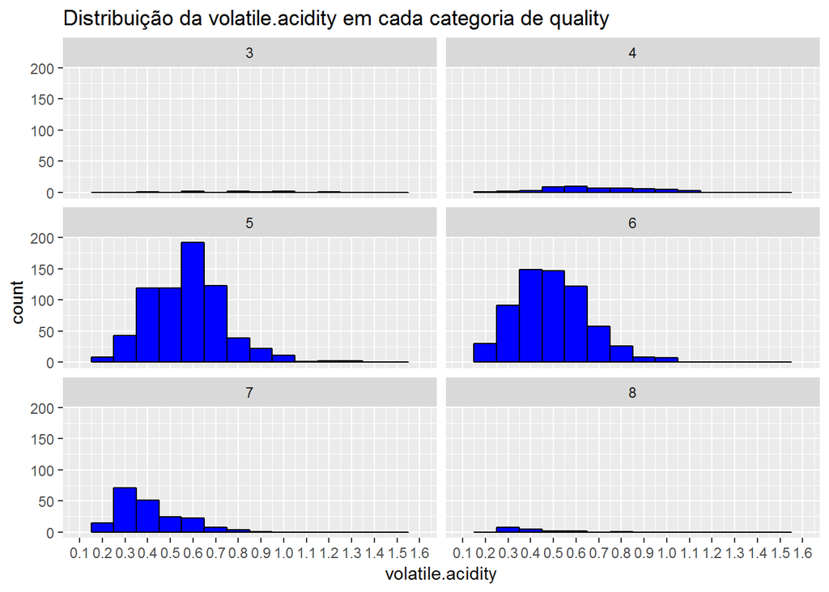

```r
ggplot(data = wine, aes(x=volatile.acidity))+
  geom_histogram(binwidth = 0.1, color = 'black', fill = 'blue')+
  scale_x_continuous(limits = c(0.1, 1.6), breaks = seq(0,1.6,0.1))+
  facet_wrap(  ~ quality, ncol=2)+
  labs(title = 'Distribuição da volatile.acidity em cada categoria de quality')
```

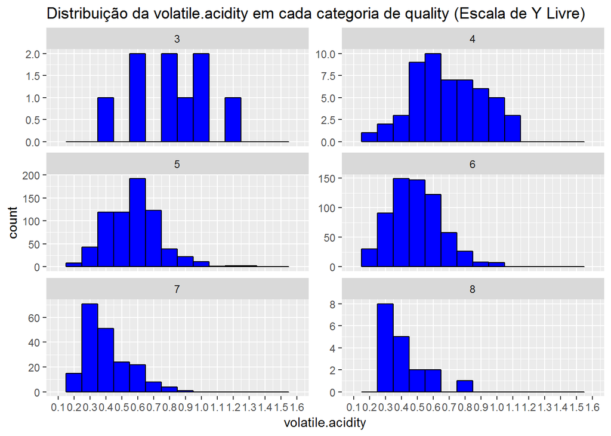

```r
ggplot(data = wine, aes(x=volatile.acidity))+
  geom_histogram(binwidth = 0.1, color = 'black', fill = 'blue')+
  scale_x_continuous(limits = c(0.1, 1.6), breaks = seq(0,1.6,0.1))+
  facet_wrap(  ~ quality, ncol=2, scales = 'free_y')+
  labs(title = 'Distribuição da volatile.acidity em cada categoria de quality (Escala de Y Livre)')
```

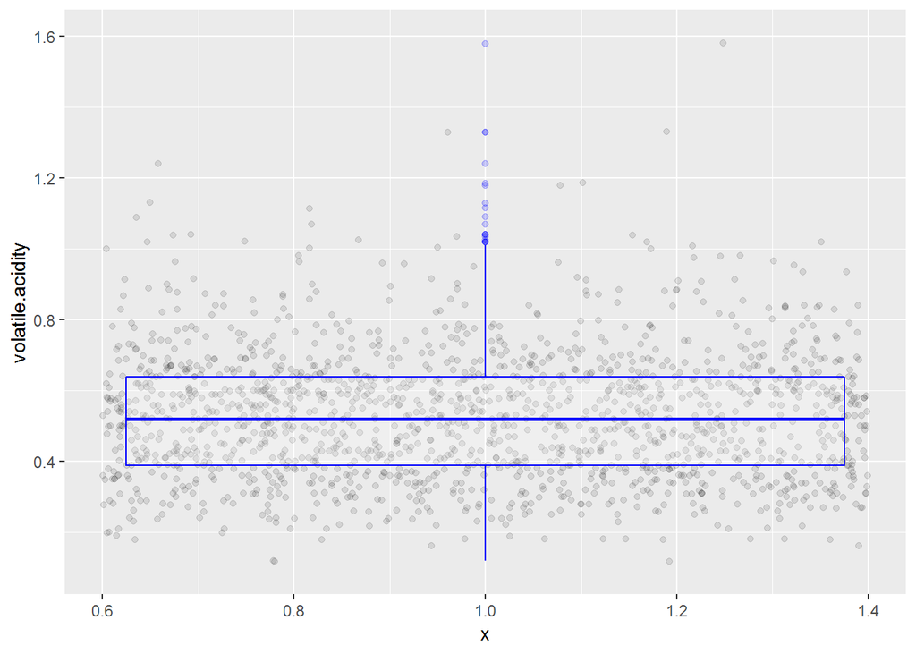

```r
ggplot(wine, aes( x = 1, y = volatile.acidity ), xlab('Count of wines') ) +
               geom_jitter(alpha = 0.1 ) + # Alpha = 10% (10 pontos para virar um ponto completo)
               geom_boxplot(alpha = 0.2, color = 'blue' ) +
               scale_y_continuous(lim = c(0.1, 1.6))
```

```r
by(wine$volatile.acidity, wine$quality, sum)
```

```
## wine$quality: 3
## [1] 8.845
## --------------------------------------------------------
## wine$quality: 4
## [1] 36.78
## --------------------------------------------------------
## wine$quality: 5
## [1] 392.965
## --------------------------------------------------------
## wine$quality: 6
## [1] 317.395
## --------------------------------------------------------
## wine$quality: 7
## [1] 80.38
## --------------------------------------------------------
## wine$quality: 8
## [1] 7.62
```

```r
by(wine$volatile.acidity, wine$quality, summary)
```

```
## wine$quality: 3
##    Min. 1st Qu.  Median    Mean 3rd Qu.    Max.
##  0.4400  0.6475  0.8450  0.8845  1.0100  1.5800
## --------------------------------------------------------
## wine$quality: 4
##    Min. 1st Qu.  Median    Mean 3rd Qu.    Max.
##   0.230   0.530   0.670   0.694   0.870   1.130
## --------------------------------------------------------
## wine$quality: 5
##    Min. 1st Qu.  Median    Mean 3rd Qu.    Max.
##   0.180   0.460   0.580   0.577   0.670   1.330
## --------------------------------------------------------
## wine$quality: 6
##    Min. 1st Qu.  Median    Mean 3rd Qu.    Max.
##  0.1600  0.3800  0.4900  0.4975  0.6000  1.0400
## --------------------------------------------------------
## wine$quality: 7
##    Min. 1st Qu.  Median    Mean 3rd Qu.    Max.
##  0.1200  0.3000  0.3700  0.4039  0.4850  0.9150
## --------------------------------------------------------
## wine$quality: 8
##    Min. 1st Qu.  Median    Mean 3rd Qu.    Max.
##  0.2600  0.3350  0.3700  0.4233  0.4725  0.8500
```

#### “citric.acid”

Def: Found in small quantities, citric acid can add ‘freshness’ and flavor to wines

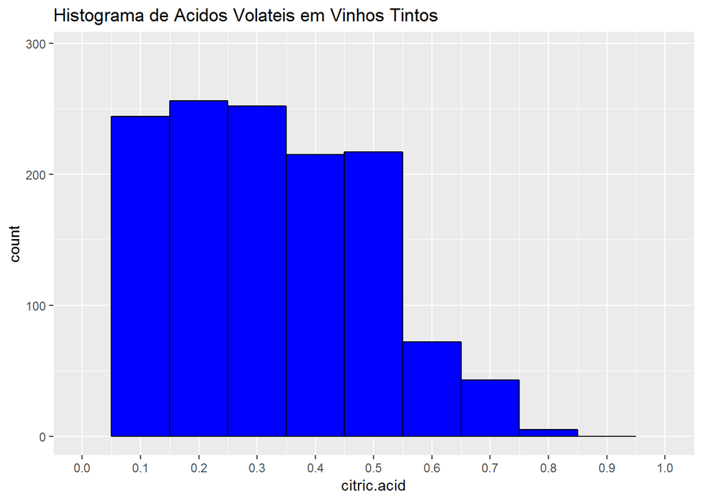

```r
ggplot(data = wine, aes(x=citric.acid))+
  geom_histogram(binwidth = 0.1, color = 'black', fill = 'blue')+
  scale_x_continuous(limits = c(0, 1), breaks = seq(0,1,0.1))+
  labs(title = 'Histograma de Acidos Volateis em Vinhos Tintos')
```

Sobre o ácido citrico, vemos que a maioria das amostras estão concentradas entre 0.1 e 0.5, vamos comparar com a qualidade dos vinhos para descobrir se quanto melhor o vinho menor o ácido citrico encontrado.

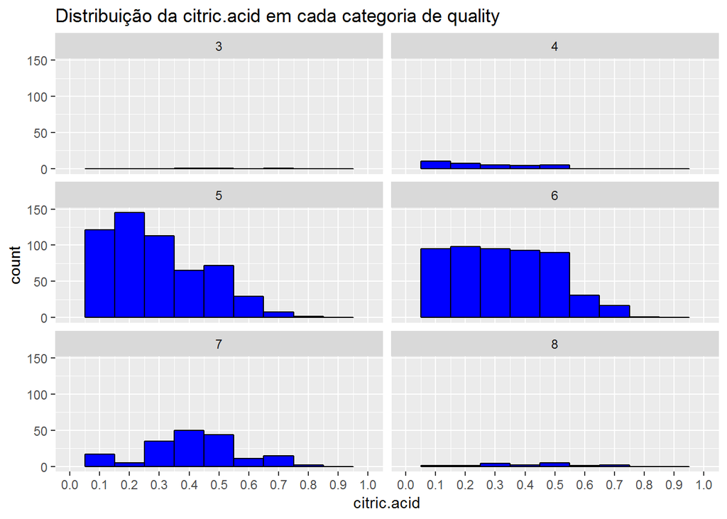

```r
ggplot(data = wine, aes(x=citric.acid))+
  geom_histogram(binwidth = 0.1, color = 'black', fill = 'blue')+
  scale_x_continuous(limits = c(0, 1), breaks = seq(0,1,0.1))+
  facet_wrap(  ~ quality, ncol=2)+
  labs(title = 'Distribuição da citric.acid em cada categoria de quality')
```

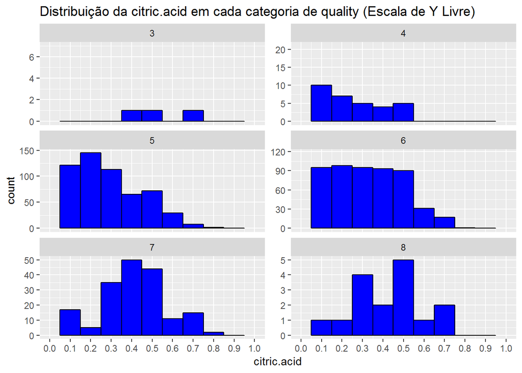

```r
ggplot(data = wine, aes(x=citric.acid))+
  geom_histogram(binwidth = 0.1, color = 'black', fill = 'blue')+
  scale_x_continuous(limits = c(0, 1), breaks = seq(0,1,0.1))+
  facet_wrap(  ~ quality, ncol=2, scales = 'free_y')+
  labs(title = 'Distribuição da citric.acid em cada categoria de quality (Escala de Y Livre)')
```

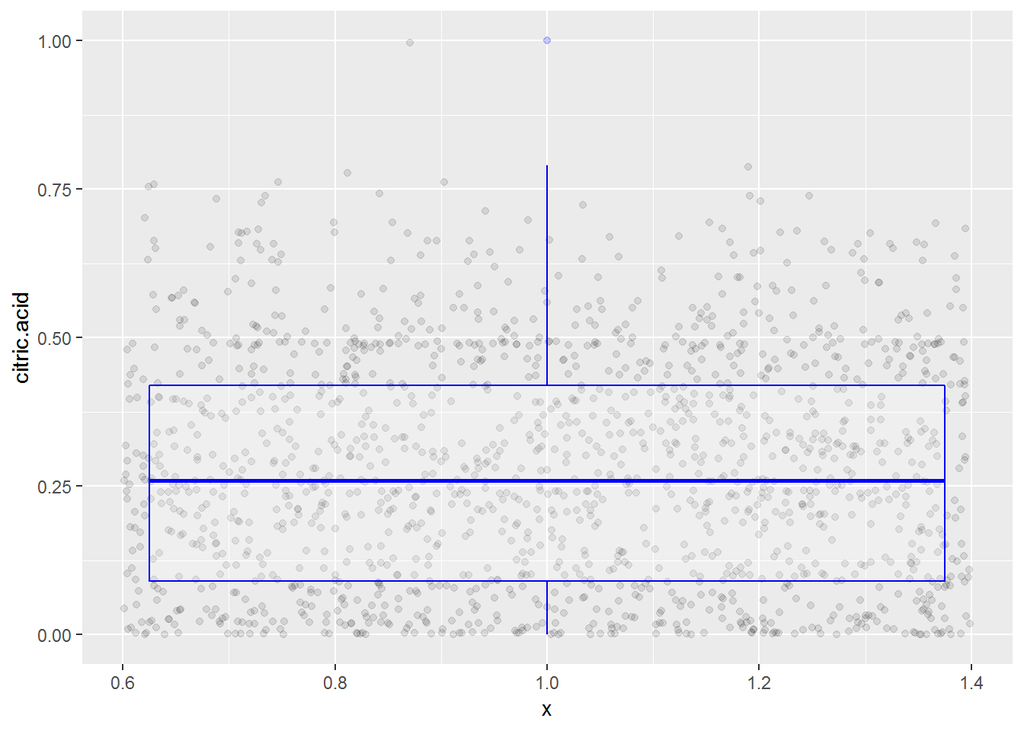

```r
ggplot(wine, aes( x = 1, y = citric.acid ), xlab('Count of wines') ) +
               geom_jitter(alpha = 0.1 ) + # Alpha = 10% (10 pontos para virar um ponto completo)
               geom_boxplot(alpha = 0.2, color = 'blue' ) +
               scale_y_continuous(lim = c(0, 1))
```

```r
by(wine$citric.acid, wine$quality, sum)
```

```
## wine$quality: 3
## [1] 1.71
## --------------------------------------------------------
## wine$quality: 4
## [1] 9.23
## --------------------------------------------------------
## wine$quality: 5
## [1] 165.95
## --------------------------------------------------------
## wine$quality: 6
## [1] 174.7
## --------------------------------------------------------
## wine$quality: 7
## [1] 74.66
## --------------------------------------------------------
## wine$quality: 8
## [1] 7.04
```

```r
by(wine$citric.acid, wine$quality, summary)
```

```
## wine$quality: 3
##    Min. 1st Qu.  Median    Mean 3rd Qu.    Max.
##  0.0000  0.0050  0.0350  0.1710  0.3275  0.6600
## --------------------------------------------------------
## wine$quality: 4
##    Min. 1st Qu.  Median    Mean 3rd Qu.    Max.
##  0.0000  0.0300  0.0900  0.1742  0.2700  1.0000
## --------------------------------------------------------
## wine$quality: 5
##    Min. 1st Qu.  Median    Mean 3rd Qu.    Max.
##  0.0000  0.0900  0.2300  0.2437  0.3600  0.7900
## --------------------------------------------------------
## wine$quality: 6
##    Min. 1st Qu.  Median    Mean 3rd Qu.    Max.
##  0.0000  0.0900  0.2600  0.2738  0.4300  0.7800
## --------------------------------------------------------
## wine$quality: 7
##    Min. 1st Qu.  Median    Mean 3rd Qu.    Max.
##  0.0000  0.3050  0.4000  0.3752  0.4900  0.7600
## --------------------------------------------------------
## wine$quality: 8
##    Min. 1st Qu.  Median    Mean 3rd Qu.    Max.
##  0.0300  0.3025  0.4200  0.3911  0.5300  0.7200
```

Ao contrario do que imaginava inicialmente, as melhores categorias (7 e 8) mostraram que tem boas quantidades de vinhos com altos indices de Acido Citrico.

Confirmamos isto olhando o crescimento da média conforme avançamos pelas quantidades

#### “residual.sugar”

Def: The amount of sugar remaining after fermentation stops, it’s rare to find wines with less than 1 gram/liter and wines with greater than 45 grams/liter are considered sweet

Baseado na definição, procurei saber qual era a escala de doçura dos vinhos tintos. http://www.winedryness.com/

```r
wine$sweetness <- ifelse(wine$residual.sugar <= 0.900, 'Very Dry', # Primeiro Quartil
                      ifelse(wine$residual.sugar < 1.900, 'Off Dry', # Segundo Quartil
                             ifelse(wine$residual.sugar < 2.200, 'Medium',# Terceiro Quartil
                                    ifelse(wine$residual.sugar < 2.600, 'Sweet', 'Very Sweet'))))

wine$sweetness <- ordered(wine$sweetness,levels = c('Very Dry','Off Dry','Medium','Sweet','Very Sweet'))

table(wine$sweetness)
```

```
##
##   Very Dry    Off Dry     Medium      Sweet Very Sweet
##          2        345        405        413        434
```

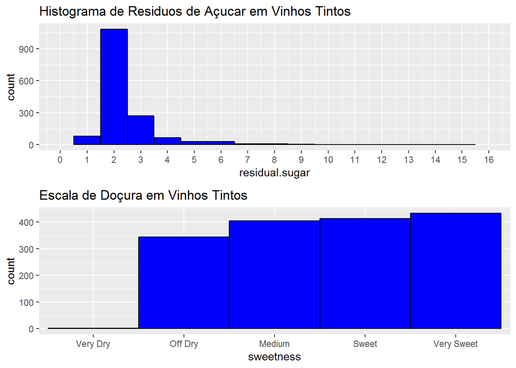

```r
grid.arrange(ggplot(data = wine, aes(x=residual.sugar))+
               geom_histogram(binwidth = 1, color = 'black', fill = 'blue')+
               scale_x_continuous(limits = c(0, 16), breaks = seq(0,16,1))+
               labs(title = 'Histograma de Residuos de Açucar em Vinhos Tintos'),
             ggplot(data = wine, aes(x = sweetness)) +
               geom_bar(width = 1, color = 'black',fill = I('blue'))+
               labs(title = 'Escala de Doçura em Vinhos Tintos'))
```

Nesta variavel percebi que temos uma grande concentração de amostras entre 1 e 6, mas temos uma cauda extramemente longa pois existem poucas amostras com um indice de açucar muito alto.

Tambem vemos que a escala que eu fiz baseado na função *QUANTILE* foi afetada por estes outliers.

Abaixo mostramos o mesmo grafico aplicando o limite aonde se concentram 95% das amostras, para uma analise mais precisa.

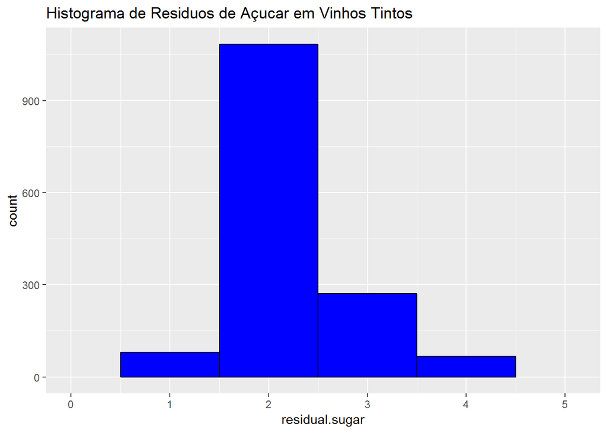

```r
ggplot(data = wine, aes(x=residual.sugar))+
  geom_histogram(binwidth = 1, color = 'black', fill = 'blue')+
  xlim(0, quantile(wine$residual.sugar, 0.95))+
  #scale_x_continuous(breaks = seq(0,quantile(wine$residual.sugar, 0.95),1))+
  labs(title = 'Histograma de Residuos de Açucar em Vinhos Tintos')
```

```r
  #ggplot(data = wine, aes(x=fixed.acidity))+
#  geom_histogram(binwidth = 0.05, color = 'black', fill = 'blue')+
#  xlim(0, quantile(wine$fixed.acidity, 0.98))+
```

Aqui o histograma parece melhor distribuido, sem os outliers puxando a cauda excessivamente longa. É bom lembrar, que este corte é apenas para melhor visualização da massa de dados, para os outros dados não iremos filtrar as amostras.

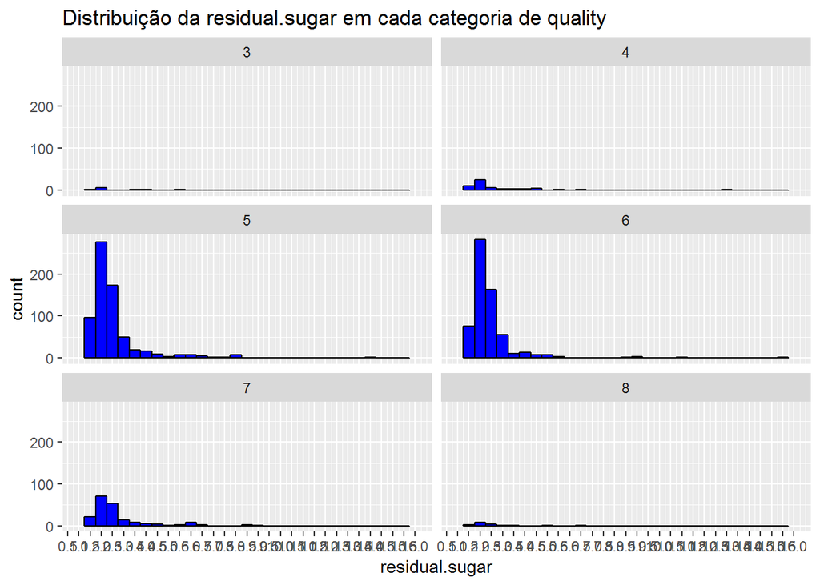

```r
ggplot(data = wine, aes(x=residual.sugar))+
  geom_histogram(binwidth = 0.5, color = 'black', fill = 'blue')+
  scale_x_continuous(limits = c(1, 16), breaks = seq(0,16,0.5))+
  facet_wrap(  ~ quality, ncol=2)+
  labs(title = 'Distribuição da residual.sugar em cada categoria de quality')
```

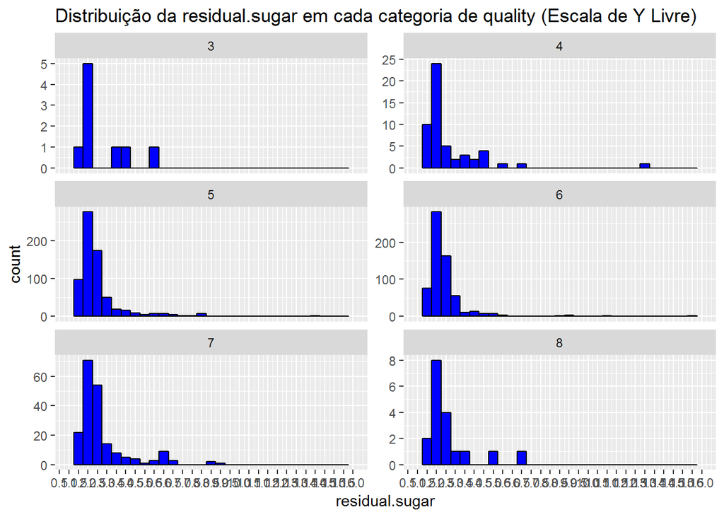

```r
ggplot(data = wine, aes(x=residual.sugar))+
  geom_histogram(binwidth = 0.5, color = 'black', fill = 'blue')+
  scale_x_continuous(limits = c(1, 16), breaks = seq(0,16,0.5))+
  facet_wrap(  ~ quality, ncol=2, scales = 'free_y')+
  labs(title = 'Distribuição da residual.sugar em cada categoria de quality (Escala de Y Livre)')
```

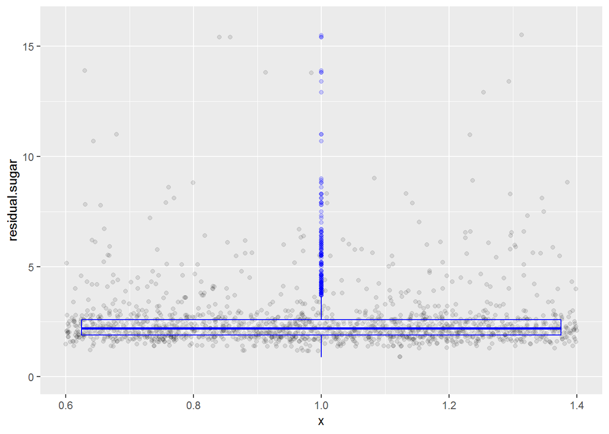

```r
ggplot(wine, aes( x = 1, y = residual.sugar ), xlab('Count of wines') ) +
               geom_jitter(alpha = 0.1 ) + # Alpha = 10% (10 pontos para virar um ponto completo)
               geom_boxplot(alpha = 0.2, color = 'blue' ) +
               scale_y_continuous(lim = c(0, 16))
```

```r
by(wine$residual.sugar, wine$quality, sum)
```

```
## wine$quality: 3
## [1] 26.35
## --------------------------------------------------------
## wine$quality: 4
## [1] 142.8
## --------------------------------------------------------
## wine$quality: 5
## [1] 1722.15
## --------------------------------------------------------
## wine$quality: 6
## [1] 1580.45
## --------------------------------------------------------
## wine$quality: 7
## [1] 541.4
## --------------------------------------------------------
## wine$quality: 8
## [1] 46.4
```

```r
by(wine$residual.sugar, wine$quality, summary)
```

```
## wine$quality: 3
##    Min. 1st Qu.  Median    Mean 3rd Qu.    Max.
##   1.200   1.875   2.100   2.635   3.100   5.700
## --------------------------------------------------------
## wine$quality: 4
##    Min. 1st Qu.  Median    Mean 3rd Qu.    Max.
##   1.300   1.900   2.100   2.694   2.800  12.900
## --------------------------------------------------------
## wine$quality: 5
##    Min. 1st Qu.  Median    Mean 3rd Qu.    Max.
##   1.200   1.900   2.200   2.529   2.600  15.500
## --------------------------------------------------------
## wine$quality: 6
##    Min. 1st Qu.  Median    Mean 3rd Qu.    Max.
##   0.900   1.900   2.200   2.477   2.500  15.400
## --------------------------------------------------------
## wine$quality: 7
##    Min. 1st Qu.  Median    Mean 3rd Qu.    Max.
##   1.200   2.000   2.300   2.721   2.750   8.900
## --------------------------------------------------------
## wine$quality: 8
##    Min. 1st Qu.  Median    Mean 3rd Qu.    Max.
##   1.400   1.800   2.100   2.578   2.600   6.400
```

Pelo sccaterplot gerado, fica mais fácil percebemos que a os vinhos mais doces são mais escassos e nos mostram que são outliers.

#### “chlorides”

Def: The amount of salt in the wine

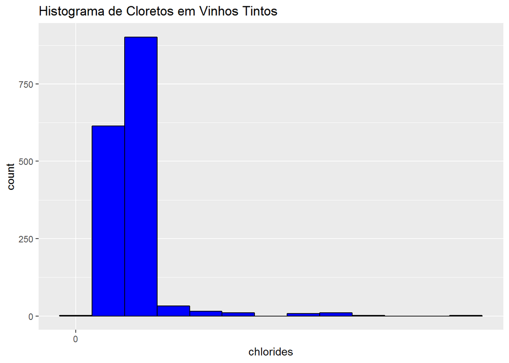

```r
ggplot(data = wine, aes(x=chlorides))+
  geom_histogram(binwidth = 0.05, color = 'black', fill = 'blue')+
  scale_x_continuous(breaks = seq(0,0.05,0.6))+
  labs(title = 'Histograma de Cloretos em Vinhos Tintos')
```

Para o atributo chlorides, precisei diminuir o binwidth para 0.05 pois o intervalo é muito pequeno. Ele lembra o residual.sugar por sua cauda longa e outliers

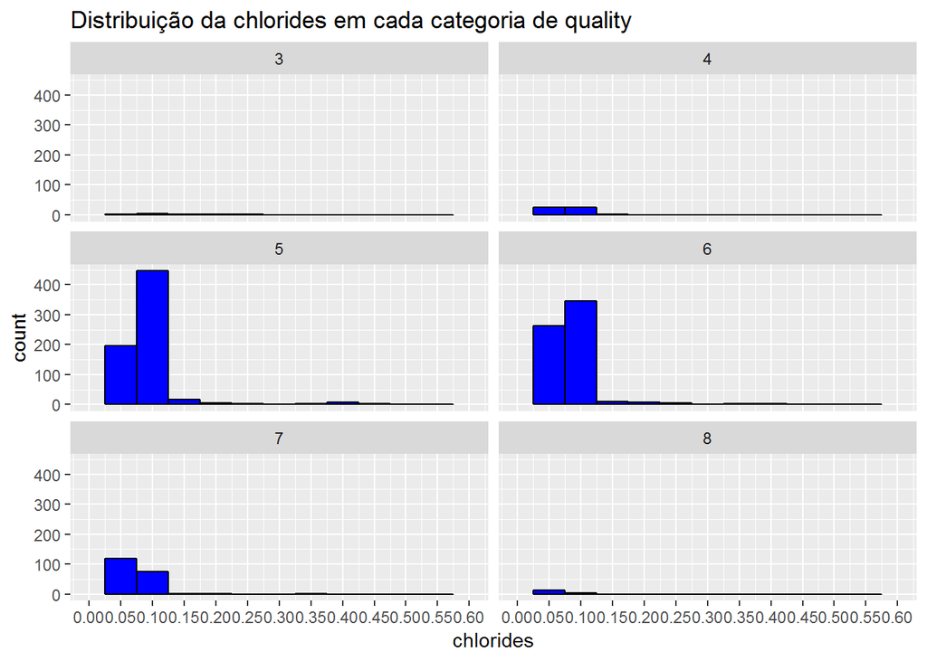

```r
ggplot(data = wine, aes(x=chlorides))+
  geom_histogram(binwidth = 0.05, color = 'black', fill = 'blue')+
  scale_x_continuous(limits = c(0, 0.6), breaks = seq(0,0.6,0.05))+
  facet_wrap(  ~ quality, ncol=2)+
  labs(title = 'Distribuição da chlorides em cada categoria de quality')
```

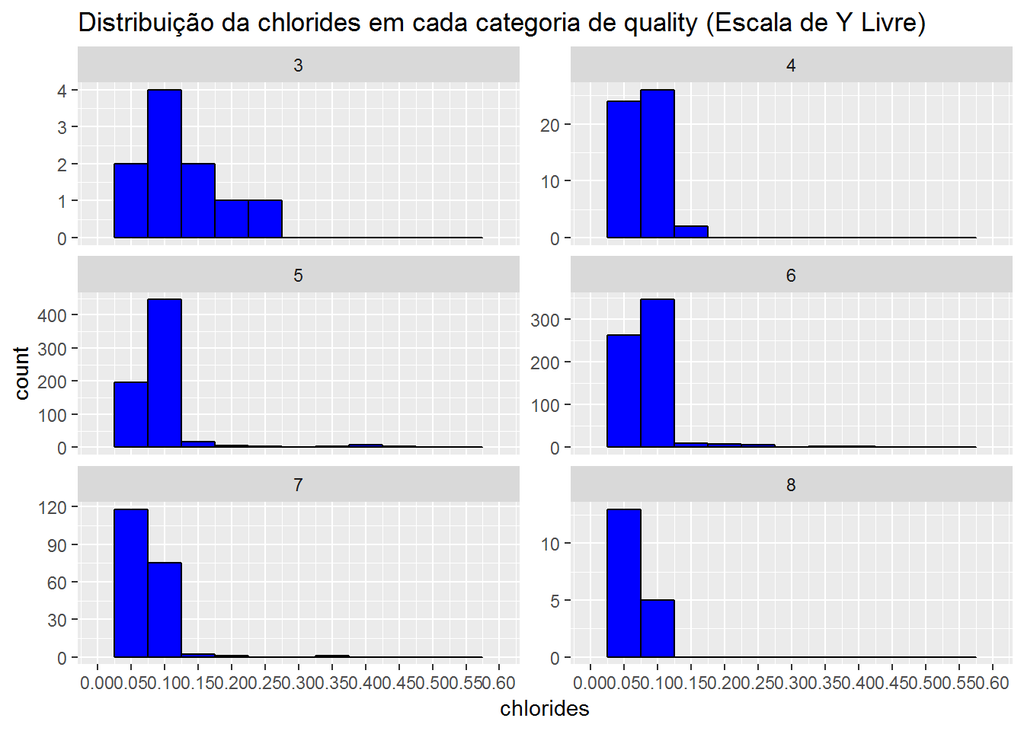

```r
ggplot(data = wine, aes(x=chlorides))+
  geom_histogram(binwidth = 0.05, color = 'black', fill = 'blue')+
  scale_x_continuous(limits = c(0, 0.6), breaks = seq(0,0.6,0.05))+
  facet_wrap(  ~ quality, ncol=2, scales = 'free_y')+
  labs(title = 'Distribuição da chlorides em cada categoria de quality (Escala de Y Livre)')
```

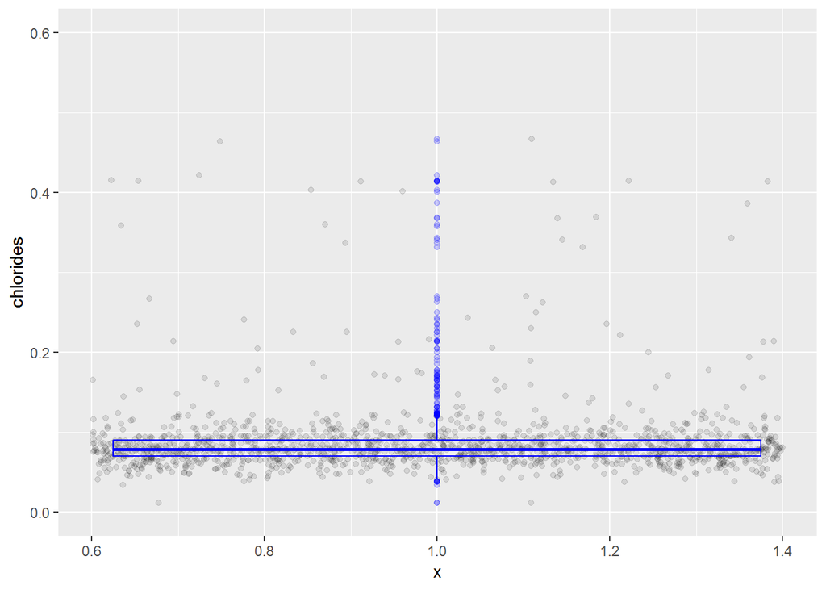

```r
ggplot(wine, aes( x = 1, y = chlorides ), xlab('Count of wines') ) +
               geom_jitter(alpha = 0.1 ) + # Alpha = 10% (10 pontos para virar um ponto completo)
               geom_boxplot(alpha = 0.2, color = 'blue' ) +
               scale_y_continuous(lim = c(0, 0.6))
```

```r
by(wine$chlorides, wine$quality, sum)
```

```
## wine$quality: 3
## [1] 1.225
## --------------------------------------------------------
## wine$quality: 4
## [1] 4.806
## --------------------------------------------------------
## wine$quality: 5
## [1] 63.153
## --------------------------------------------------------
## wine$quality: 6
## [1] 54.202
## --------------------------------------------------------
## wine$quality: 7
## [1] 15.241
## --------------------------------------------------------
## wine$quality: 8
## [1] 1.232
```

```r
by(wine$chlorides, wine$quality, summary)
```

```
## wine$quality: 3
##    Min. 1st Qu.  Median    Mean 3rd Qu.    Max.
##  0.0610  0.0790  0.0905  0.1225  0.1430  0.2670
## --------------------------------------------------------
## wine$quality: 4
##    Min. 1st Qu.  Median    Mean 3rd Qu.    Max.
## 0.04500 0.06700 0.08000 0.09068 0.08900 0.61000
## --------------------------------------------------------
## wine$quality: 5
##    Min. 1st Qu.  Median    Mean 3rd Qu.    Max.
## 0.03900 0.07400 0.08100 0.09274 0.09400 0.61100
## --------------------------------------------------------
## wine$quality: 6
##    Min. 1st Qu.  Median    Mean 3rd Qu.    Max.
## 0.03400 0.06825 0.07800 0.08496 0.08800 0.41500
## --------------------------------------------------------
## wine$quality: 7
##    Min. 1st Qu.  Median    Mean 3rd Qu.    Max.
## 0.01200 0.06200 0.07300 0.07659 0.08700 0.35800
## --------------------------------------------------------
## wine$quality: 8
##    Min. 1st Qu.  Median    Mean 3rd Qu.    Max.
## 0.04400 0.06200 0.07050 0.06844 0.07550 0.08600
```

Apliquei um limite nos histogramas para melhor visualização devido aos outliers, mas percebemos uma diminuição no cloreto conforme a qualidade do vinho aumenta

#### “free.sulfur.dioxide”

Def: The free form of SO2 exists in equilibrium between molecular SO2 (as a dissolved gas) and bisulfite ion; it prevents microbial growth and the oxidation of wine

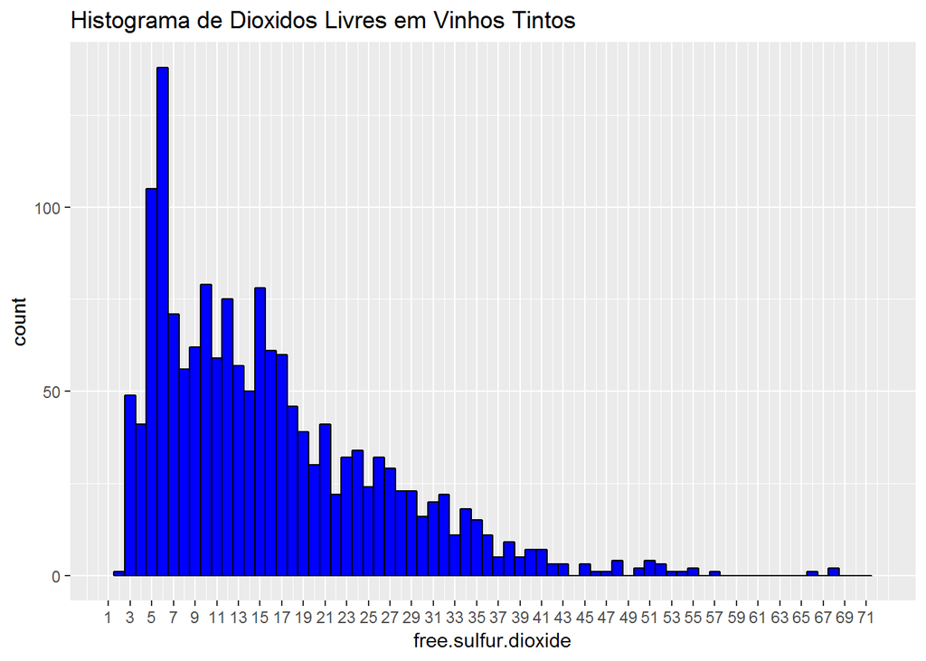

```r
ggplot(data = wine, aes(x=free.sulfur.dioxide))+
  geom_histogram(binwidth = 1, color = 'black', fill = 'blue')+
  scale_x_continuous(limits = c(1,72), breaks = seq(1,72,2))+
  labs(title = 'Histograma de Dioxidos Livres em Vinhos Tintos')
```

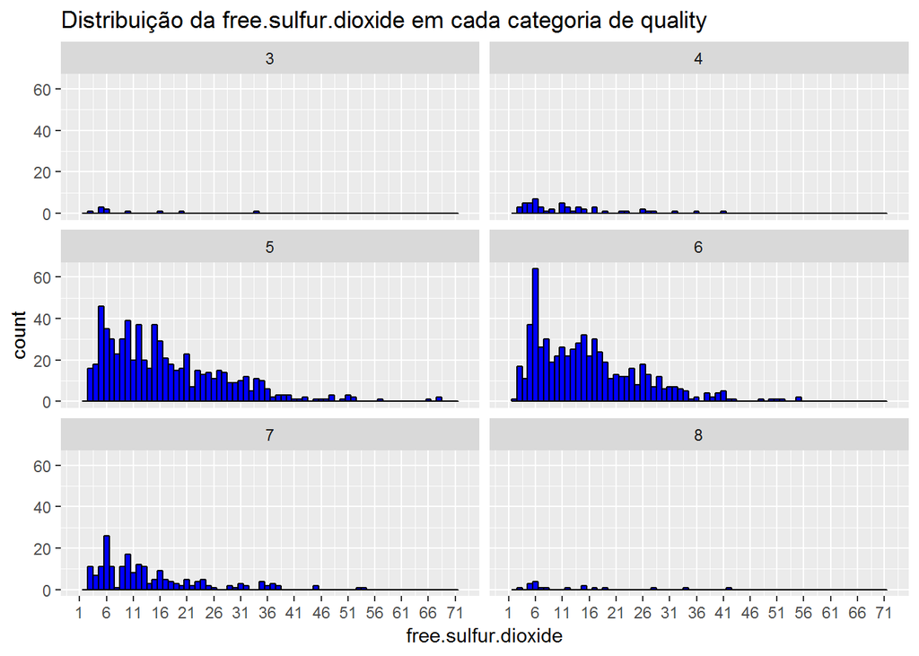

```r
ggplot(data = wine, aes(x=free.sulfur.dioxide))+
  geom_histogram(binwidth = 1, color = 'black', fill = 'blue')+
  scale_x_continuous(limits = c(1,72), breaks = seq(1,72,5))+
  facet_wrap(  ~ quality, ncol=2)+
  labs(title = 'Distribuição da free.sulfur.dioxide em cada categoria de quality')
```

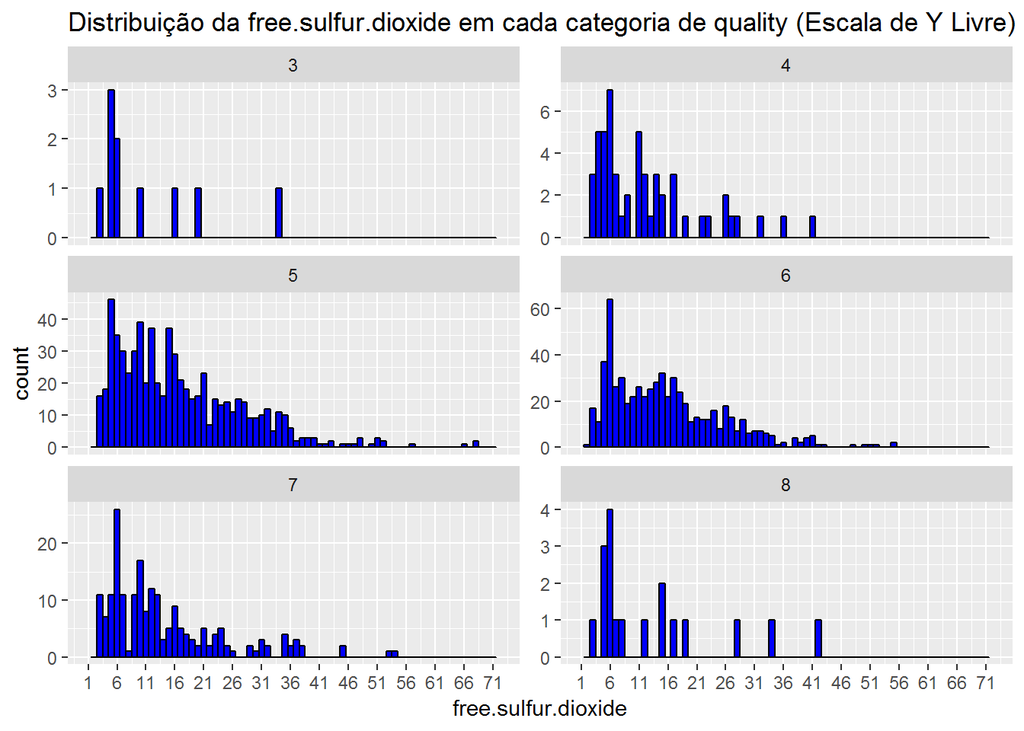

```r
ggplot(data = wine, aes(x=free.sulfur.dioxide))+
  geom_histogram(binwidth = 1, color = 'black', fill = 'blue')+
  scale_x_continuous(limits = c(1,72), breaks = seq(1,72,5))+
  facet_wrap(  ~ quality, ncol=2, scales = 'free_y')+
  labs(title = 'Distribuição da free.sulfur.dioxide em cada categoria de quality (Escala de Y Livre)')
```

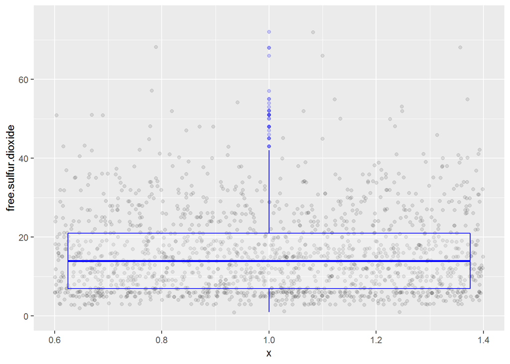

```r
ggplot(wine, aes( x = 1, y = free.sulfur.dioxide ), xlab('Count of wines') ) +
               geom_jitter(alpha = 0.1 ) + # Alpha = 10% (10 pontos para virar um ponto completo)
               geom_boxplot(alpha = 0.2, color = 'blue' ) +
               scale_y_continuous(lim = c(0, 75))
```

```r
by(wine$free.sulfur.dioxide, wine$quality, sum)
```

```
## wine$quality: 3
## [1] 110
## --------------------------------------------------------
## wine$quality: 4
## [1] 650
## --------------------------------------------------------
## wine$quality: 5
## [1] 11566
## --------------------------------------------------------
## wine$quality: 6
## [1] 10024
## --------------------------------------------------------
## wine$quality: 7
## [1] 2795
## --------------------------------------------------------
## wine$quality: 8
## [1] 239
```

```r
by(wine$free.sulfur.dioxide, wine$quality, summary)
```

```
## wine$quality: 3
##    Min. 1st Qu.  Median    Mean 3rd Qu.    Max.
##     3.0     5.0     6.0    11.0    14.5    34.0
## --------------------------------------------------------
## wine$quality: 4
##    Min. 1st Qu.  Median    Mean 3rd Qu.    Max.
##    3.00    6.00   11.00   12.26   15.00   41.00
## --------------------------------------------------------
## wine$quality: 5
##    Min. 1st Qu.  Median    Mean 3rd Qu.    Max.
##    3.00    9.00   15.00   16.98   23.00   68.00
## --------------------------------------------------------
## wine$quality: 6
##    Min. 1st Qu.  Median    Mean 3rd Qu.    Max.
##    1.00    8.00   14.00   15.71   21.00   72.00
## --------------------------------------------------------
## wine$quality: 7
##    Min. 1st Qu.  Median    Mean 3rd Qu.    Max.
##    3.00    6.00   11.00   14.05   18.00   54.00
## --------------------------------------------------------
## wine$quality: 8
##    Min. 1st Qu.  Median    Mean 3rd Qu.    Max.
##    3.00    6.00    7.50   13.28   16.50   42.00
```

#### “total.sulfur.dioxide”

Def: Amount of free and bound forms of S02; in low concentrations, SO2 is mostly undetectable in wine, but at free SO2 concentrations over 50 ppm, SO2 becomes evident in the nose and taste of wine

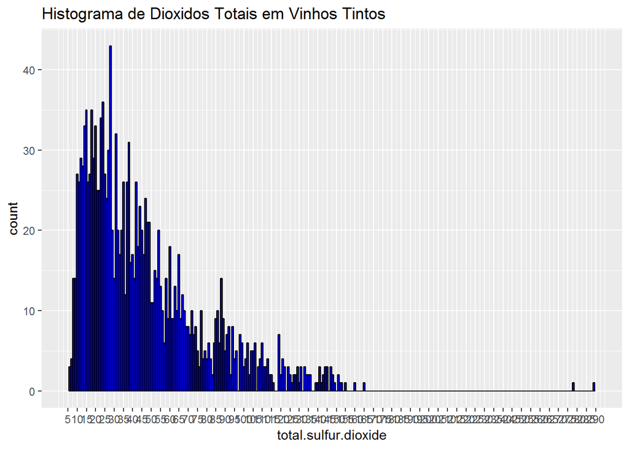

```r
ggplot(data = wine, aes(x=total.sulfur.dioxide))+
  geom_histogram(binwidth = 1, color = 'black', fill = 'blue')+
  scale_x_continuous(limits = c(5,290), breaks = seq(5,290,5))+
  labs(title = 'Histograma de Dioxidos Totais em Vinhos Tintos')
```

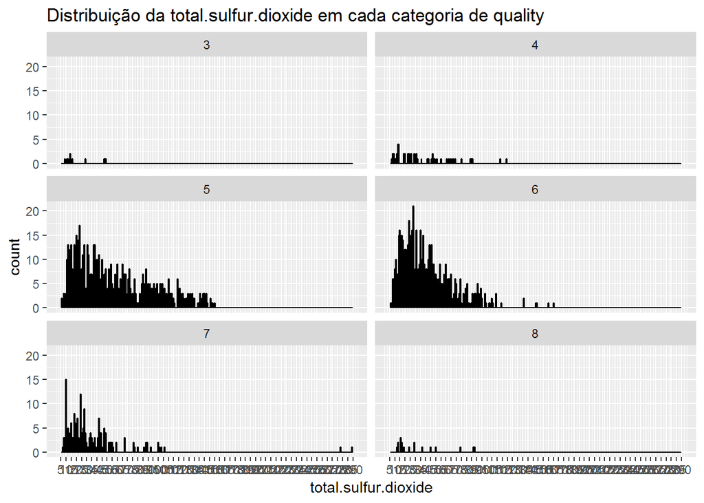

```r
ggplot(data = wine, aes(x=total.sulfur.dioxide))+
  geom_histogram(binwidth = 1, color = 'black', fill = 'blue')+
  scale_x_continuous(limits = c(5,290), breaks = seq(5,290,5))+
  facet_wrap(  ~ quality, ncol=2)+
  labs(title = 'Distribuição da total.sulfur.dioxide em cada categoria de quality')
```

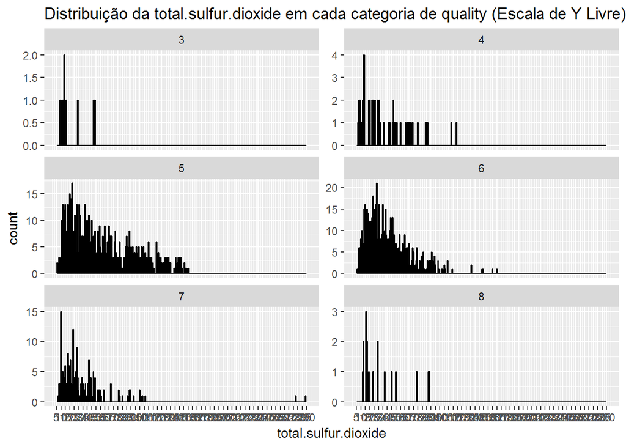

```r
ggplot(data = wine, aes(x=total.sulfur.dioxide))+
  geom_histogram(binwidth = 1, color = 'black', fill = 'blue')+
  scale_x_continuous(limits = c(5,290), breaks = seq(5,290,5))+
  facet_wrap(  ~ quality, ncol=2, scales = 'free_y')+
  labs(title = 'Distribuição da total.sulfur.dioxide em cada categoria de quality (Escala de Y Livre)')
```

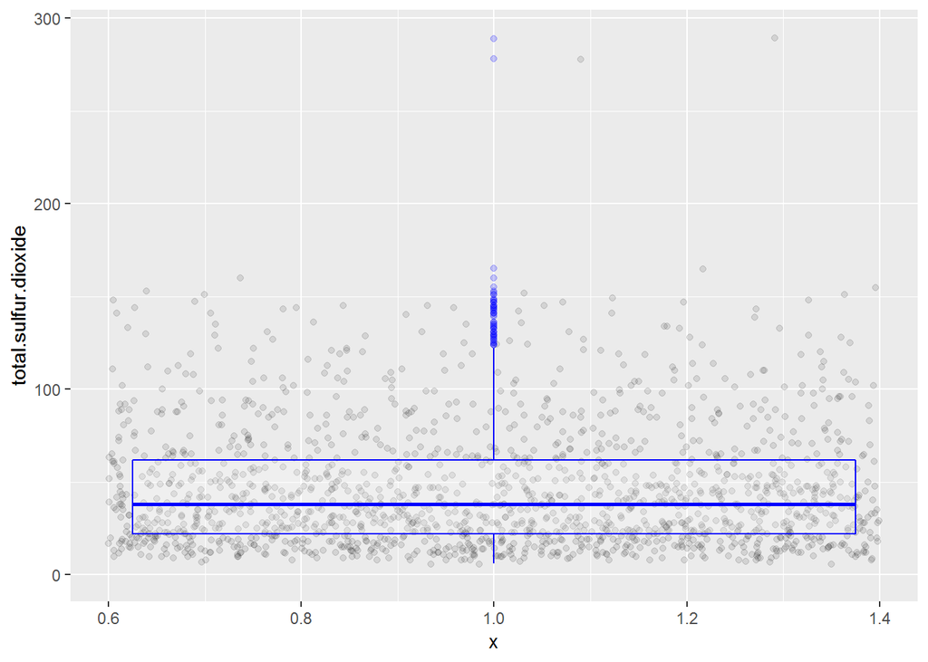

```r
ggplot(wine, aes( x = 1, y = total.sulfur.dioxide ), xlab('Count of wines') ) +
               geom_jitter(alpha = 0.1 ) + # Alpha = 10% (10 pontos para virar um ponto completo)
               geom_boxplot(alpha = 0.2, color = 'blue' ) +
               scale_y_continuous(lim = c(0, 290))
```

```r
by(wine$total.sulfur.dioxide, wine$quality, sum)
```

```
## wine$quality: 3
## [1] 249
## --------------------------------------------------------
## wine$quality: 4
## [1] 1921
## --------------------------------------------------------
## wine$quality: 5
## [1] 38486
## --------------------------------------------------------
## wine$quality: 6
## [1] 26075
## --------------------------------------------------------
## wine$quality: 7
## [1] 6969
## --------------------------------------------------------
## wine$quality: 8
## [1] 602
```

```r
by(wine$free.sulfur.dioxide, wine$quality, summary)
```

```
## wine$quality: 3
##    Min. 1st Qu.  Median    Mean 3rd Qu.    Max.
##     3.0     5.0     6.0    11.0    14.5    34.0
## --------------------------------------------------------
## wine$quality: 4
##    Min. 1st Qu.  Median    Mean 3rd Qu.    Max.
##    3.00    6.00   11.00   12.26   15.00   41.00
## --------------------------------------------------------
## wine$quality: 5
##    Min. 1st Qu.  Median    Mean 3rd Qu.    Max.
##    3.00    9.00   15.00   16.98   23.00   68.00
## --------------------------------------------------------
## wine$quality: 6
##    Min. 1st Qu.  Median    Mean 3rd Qu.    Max.
##    1.00    8.00   14.00   15.71   21.00   72.00
## --------------------------------------------------------
## wine$quality: 7
##    Min. 1st Qu.  Median    Mean 3rd Qu.    Max.
##    3.00    6.00   11.00   14.05   18.00   54.00
## --------------------------------------------------------
## wine$quality: 8
##    Min. 1st Qu.  Median    Mean 3rd Qu.    Max.
##    3.00    6.00    7.50   13.28   16.50   42.00
```

A variavel total.sulfur.dioxide parece seguir o mesmo padrão da free.sulfur.dioxide, pois são altamente correlacionadas.